**CONFIDENTIAL WORK PRODUCT – NOT FOR PUBLIC DISTRIBUTION**

[figure not shown]

The following table shows the number of divisions that would need to add language access for a given threshold. For example, if we wanted to add language access for divisions in areas where 3% or more of the population speaks Arabic, that would require 119 divisions to add Arabic ballots. If we moved the minimum to 5%, it would be 51 divisions.

| Threshold | Arabic | Spanish | Haitian | Mandarin | Vietnamese | Total |
| --- | --- | --- | --- | --- | --- | --- |
| 3% | 119 | 1146 | 103 | 390 | 228 | 1986 |
| 5% | 51 | 741 | 53 | 261 | 145 | 1251 |
| 10% | 3 | 480 | 4 | 122 | 20 | 629 |
| 15% | 0 | 341 | 4 | 52 | 5 | 402 |
| 20% | 0 | 264 | 0 | 26 | 0 | 290 |

The following charts show how many languages each division would need to add given a certain threshold. If we had a 3% threshold for all five languages, 756 divisions would need to add only one language. 6 divisions would need to add all five languages. 451 of the nearly 1,700 divisions would not need to add any language access. Increasing the threshold to 5% or 10% decreases the number of divisions requiring language access.

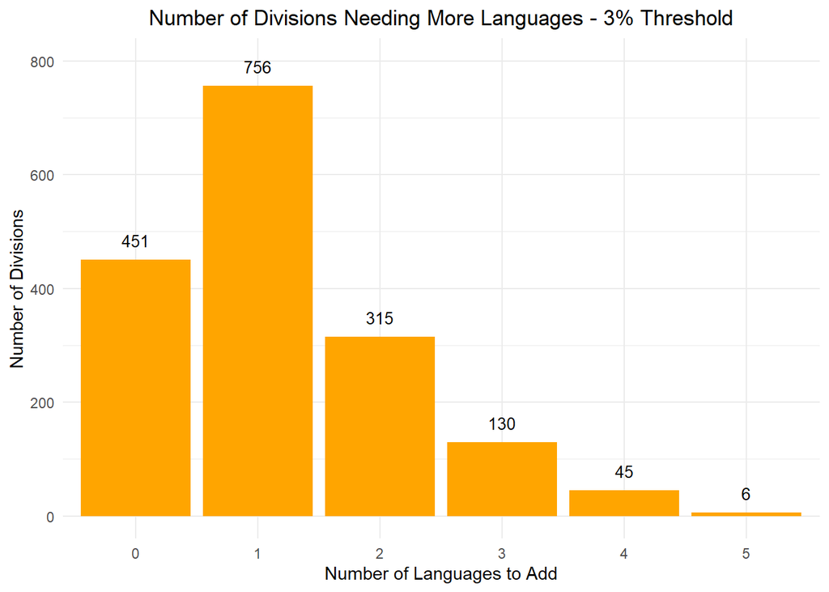

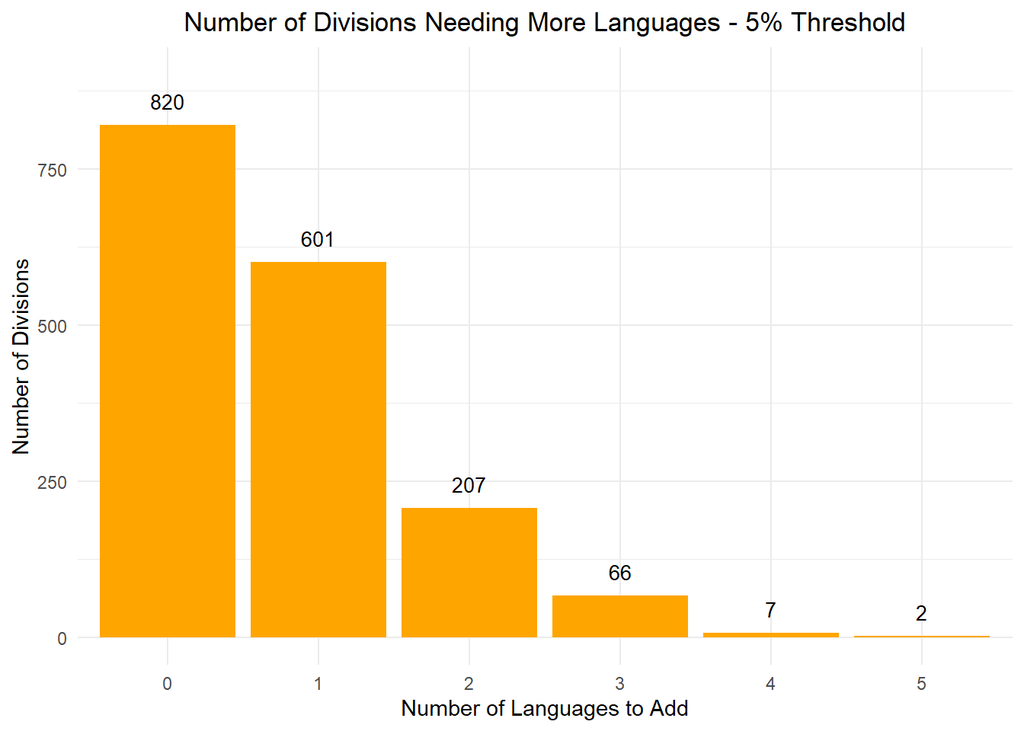

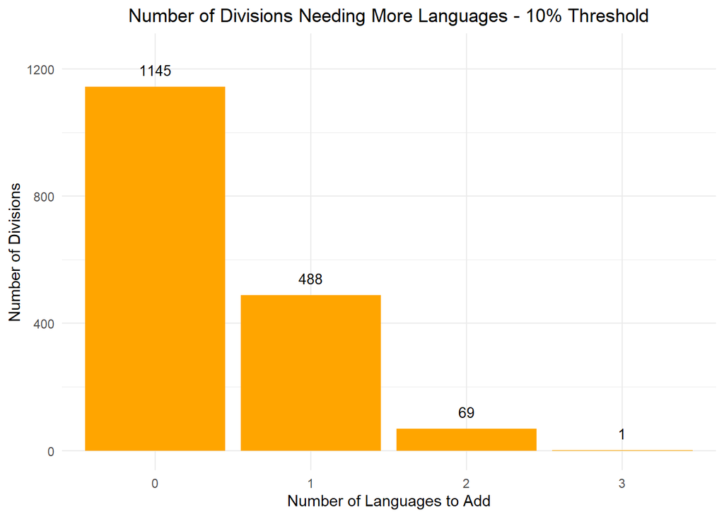

Prepared by K. Stout and M. Gall: March 2020.

Sources: 2018 ACS 5-year Estimate (Table B01001, Table B02001, Table B03003) and 2015 ACS 5-year Estimate for language data: Table B16001. Shapefiles from US Census Tracts and Philadelphia Political Divisions.